# Projet Heetch : Détection de domicile des chauffeurs

## Objectifs

- Produire une analyse à partir de données individuelles de type “trace numérique”
- Connaître les fondamentaux de l’analyse de données spatiales
- Réfléchir concrètement sur les possibilités techniques et les enjeux sociaux liés à de telles analyses

## Description

Heetch est une start-up française qui organise des services de VTC dans plusieurs villes du monde dont Casablanca. Les données sont fournies pour Casablanca pour le mois de mars 2019 avec un point GPS par minute et par véhicule. Ces données comportent un identifiant chauffeur (`driver_id`), une variable temporelle (`location_at_local_time`) et des coordonnées géographiques (`longitude` et `latitude`).

Des données supplémentaires sont ajoutées pour l’analyse : extraction de données OpenStreetMap directement depuis R et découpage administratif du Maroc téléchargé sur le [site GADM](https://gadm.org/data.html).

## Préparation des données

Charger les packages nécessaires.

```r
library(sf)           # manipulation des données spatiales
library(osmdata)      # extraction des données OpenStreetMap
library(leaflet)      # visualisation interactive avec leaflet
library(cartography)  # cartographie statistique
library(lubridate)    # manipulation des dates
library(tidyverse)    # méta-package d'Hadley Wickham
library(adehabitatHR)
library(dbscan)
library(spatstat)
library(factoextra)
library(rgdal)
```

Charger les données : découpage adminisratif et données Heetch.

```r
casaBound <- st_read("DATA/casabound.geojson")
heetchPoints <- readRDS("DATA/heetchmarchcrop.Rds")
osmFeatures <- readRDS("DATA/osmfeatures.Rds")
```

Télécharger les données OSM (routes principales, tramway) (ce travail est déjà fait et stocké dans le fichier `osmfeatures.Rds`.

```r
osmRoads <- opq(bbox = st_bbox(casaBound)) %>%
  add_osm_feature(key = "highway",
                  value = c("motorway", "trunk", "primary", "secondary", "tertiary")) %>%
  osmdata_sf()

osmTram <- opq(bbox = st_bbox(casaBound)) %>%
  add_osm_feature(key = "railway",
                  value = "tram") %>%
  osmdata_sf()

osmTramstop <- opq(bbox = st_bbox(casaBound)) %>%
  add_osm_feature(key = "railway",
                  value = "tram_stop") %>%
  osmdata_sf()
```

Cartographier les données.

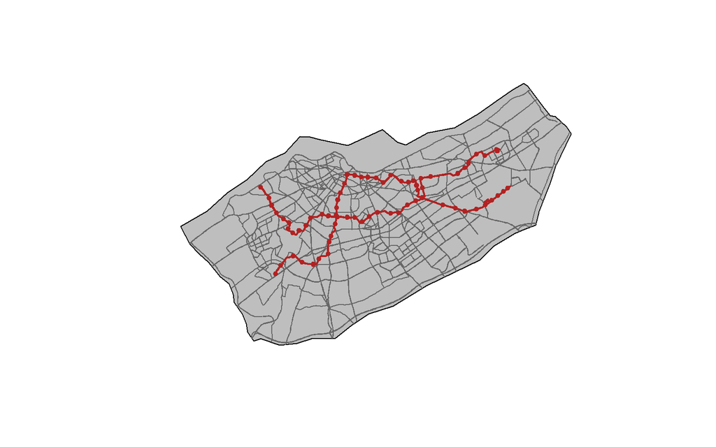

```r
plot(casaBound$geometry, col = "grey")
plot(osmFeatures$roads$geometry, col = "grey40", add = TRUE)
plot(osmFeatures$tramway$geometry, col = "firebrick", lwd = 2, add = TRUE)
plot(osmFeatures$tramstop$geometry, col = "firebrick", pch = 20, add = TRUE)
```

## Propositions d’analyse

Création de variables temporelles (temps POSIX et découpé).

```r
# temps POSIX (as.POSIXct() ou fonctions de lubridate)
heetchPoints$DATE <- ymd_hms(heetchPoints$location_at_local_time, tz = "Africa/Casablanca")
heetchPoints$DATE[1] %>% as.numeric()
```

```
## [1] 1551395037
```

```r
# année, mois, jour
heetchPoints$YMD <- substr(heetchPoints$location_at_local_time, 1, 10)
heetchPoints$HMS <- substr(heetchPoints$location_at_local_time, 12, 19)
heetchPoints$HM <- substr(heetchPoints$location_at_local_time, 12, 16)
heetchPoints$HOUR <- substr(heetchPoints$location_at_local_time, 12, 13)
```

Sélection d’un seul jour (par exemple le 1r mars 2019).

```r
heetchM1 <- heetchPoints %>% filter(YMD == "2019-03-01")
```

Création d’un carroyage sur l’espace d’étude.

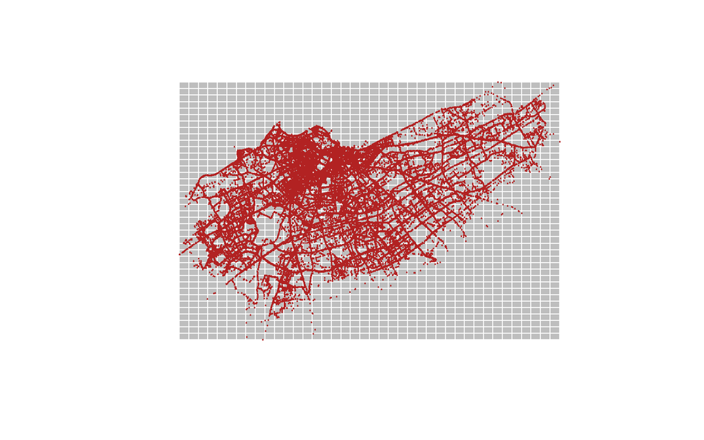

```r
casaGridgeom <- st_make_grid(x = heetchM1, n = 40)
casaGrid <- st_sf(IDGRID = seq(1, length(casaGridgeom), 1),
                  geometry = casaGridgeom)


plot(casaGrid$geometry, col = "grey", border = "white")
plot(heetchM1$geometry, pch = 20, cex = 0.3, col = "firebrick", add = TRUE)
```

Dénombrement des présences dans les carreaux.

```r
pointsInGrid <- st_contains(x = casaGrid, y = heetchM1)
```

```
## although coordinates are longitude/latitude, st_contains assumes that they are planar
```

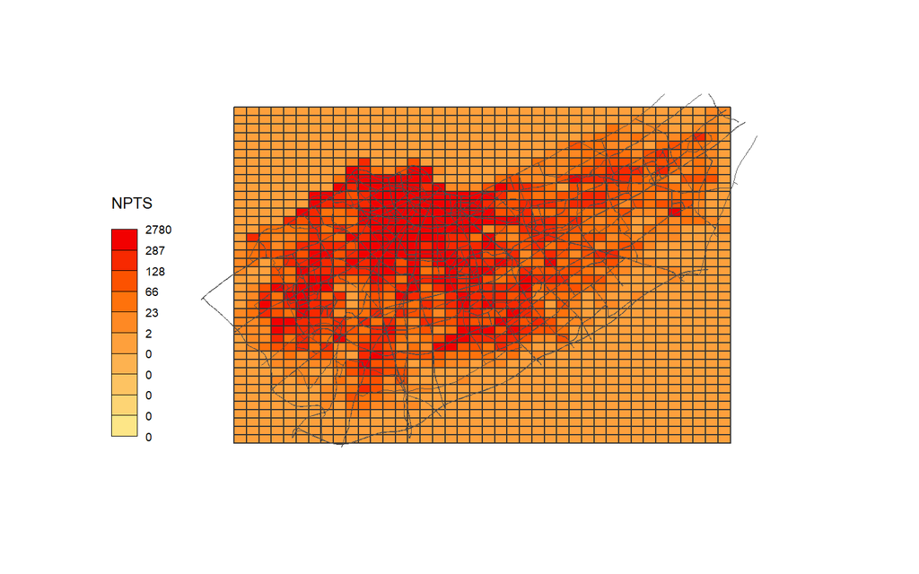

```r
casaGrid$NPTS <- sapply(X = pointsInGrid, FUN = length)

choroLayer(x = casaGrid, var = "NPTS", method = "quantile", nclass = 10, col = carto.pal(pal1 = "orange.pal", n1 = 10))
plot(osmFeatures$roads$geometry, col = "grey30", lwd = 0.6, add = TRUE)
```

## Concevoir et implémenter une fonction qui détecte le domicile

**Exemple simpliste :** le domicile est estimé au premier point enregistré de la journée.

```r
homedetector <- function(driver){
  # méthode 1
  home <- driver %>%
    arrange(location_at_local_time) %>%
    slice(1)

  # méthode 2
  minTime <- min(driver$location_at_local_time)
  home <- driver[driver$location_at_local_time == minTime, ]

  # méthode 3
  home <- driver[which.min(driver$location_at_local_time), ]

  return(home)
}
```

**Problème :** le premier point de la journée n’est pas nécessairement le premier point de la journée de travail du chauffeur (travail de nuit, etc.)

**Méthode plus robuste :** calculer un vecteur de différences de temps pour tous les jours d’un chauffeur donné. Sélectionner le point juste avant les plus grands intervalles.

```r
# sélection d'un chauffeur (tous les jours)
oneDriver <- heetchPoints %>%
  filter(driver_id == "54f25ae2-9f19-489e-8c6d-ba8ede2f0ff0") %>%
  arrange(location_at_local_time)

# calcul des différences de temps
vecDif <- oneDriver$location_at_local_time[2:nrow(oneDriver)] -
  oneDriver$location_at_local_time[1:nrow(oneDriver)-1]

# sélection des points avec seuil à 8h (480 minutes)
idOff <- which(as.numeric(vecDif) > 480)
homeList <- oneDriver[idOff, ]

leaflet() %>%
  addTiles() %>%
  addCircles(data = homeList)
```

[interactive chart not shown]

**Problème :** on récupère un semis de points et non un seul point ou une seule zone. Solutions envisageables : faire du clustering (DBSCAN par exemple), ou bien faire un carroyage, puis un dénombrement et renvoyer le carreau qui contient le maximum de points.

```r
pointsInGrid <- st_contains(x = casaGrid, y = homeList)
```

```
## although coordinates are longitude/latitude, st_contains assumes that they are planar
```

```r
casaGrid$NPTS <- sapply(X = pointsInGrid, FUN = length)
homeZone <- casaGrid[which.max(casaGrid$NPTS), ]

leaflet() %>%
  addTiles() %>%
  addPolygons(data = homeZone)
```

[interactive chart not shown]

## Affiner la détection à travers l’algorithme DBSCAN et Home Range

Dans cette partie nous avons choisi de garder la méthode des veteurs de différences temporelles. Néanmoins, deux améliorations ont été remarqués quant au résultat précédent :

- Premièrement, nous devons enlever les “Outliers” avant de déterminer une surface dans laquelle le chauffeur peut potentiellement habiter à travers l’algorithme DBSCAN. DBSCAN, est un algorithme d’apprentissage automatique non supervisé. Les algorithmes d’apprentissage automatique non supervisés sont utilisés pour classer des données non étiquetées. En d’autres termes, les échantillons utilisés pour entraîner notre modèle ne sont pas accompagnés de catégories prédéfinies. En comparaison avec d’autres algorithmes de clustering, DBSCAN est particulièrement bien adapté aux problèmes qui nécessitent la détection des outliers.
- Deuxièmement, la surface rectangulaire n’est pas forcément le type de surface optimal à considérer. En effet, le chauffeur censé stationner à côté de sa maison avant de domir, il est préférable de relier entre tous ces positions de stationnement et de conjecturer que le chauffeur habite quelque part à l’intérieur du polygone formé par ces points là. En essayant d’implémenter cette méthode à la main, nous nous sommes retrouvé avec un algorithme nommé HomeRange qui crée ce polygone-là avoir s’être débarassé des outliers. L’algorithme qui, à la base détecte la zone de besoins des animaux en répondant aux questions “Où mange-t-il?” et “Où dort-t-il?” rempli parfaitement la tâche que nous cherchons dans ce projet.

```r
coord <- st_coordinates(homeList)

db = dbscan(coord,eps = 0.005, minPts = 3, borderPoints = FALSE)
db$cluster
```

```
##  [1] 1 1 0 1 0 1 1 0 0 0 1 0 0 0 0 1 1 0 0 1 0 1 0 0 2 1
```

```r
db_clusters <- cbind(homeList, ClusterNum = db$cluster)%>%
  filter(ClusterNum == 1)
```

```r
clustered_home <- as_Spatial(db_clusters$geometry)

Home_range <- mcp(clustered_home, percent = 100)
Hr <- spTransform(Home_range, CRS("+proj=longlat +datum=WGS84"))
```

```r
leaflet() %>%
  addTiles() %>%
  addCircles(data = db_clusters$geometry) %>%
  addPolygons(data = Hr, weight = 0 ,col = alpha(1:5, 1.5)) %>%
  addPolygons(data = homeZone)
```

[interactive chart not shown]

## Hyperparameter tuning

Comme mentionné précédemment, nous devons fournir une valeur pour epsilon qui définit la distance maximale entre deux points. L’article [3] de la bibliogrpahie, décrit une approche pour déterminer automatiquement la valeur optimale pour Eps. En termes simples, nous trouvons une valeur appropriée pour epsilon en calculant la distance aux n points les plus proches pour chaque point, en triant et en traçant les résultats. Ensuite, nous cherchons à voir où le changement est le plus prononcé (pensez à l’angle entre votre bras et votre avant-bras) et nous choisissons cette valeur comme epsilon.

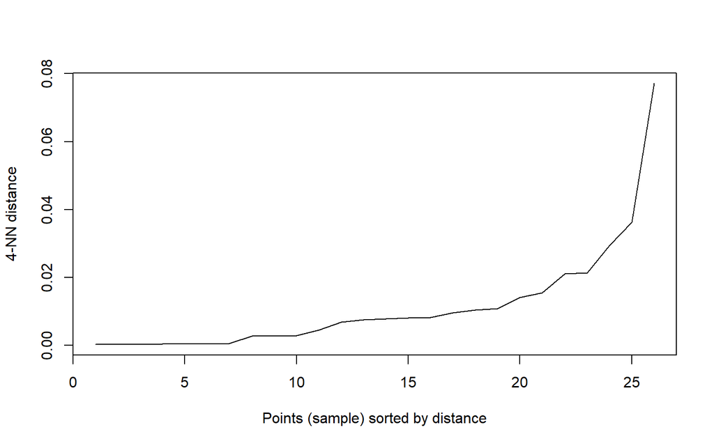

```r
kNNdistplot(coord, k =  4)
```

```r
db_new = dbscan(coord,eps = 0.002, minPts = 3, borderPoints = FALSE)
clusters_new <- cbind(homeList, ClusterNum = db_new$cluster)%>%
  filter(ClusterNum == 1)

clustered_home<- as_Spatial(clusters_new$geometry)

Home_range_new <- mcp(clustered_home, percent = 100)
Home_poly <- spTransform(Home_range_new, CRS("+proj=longlat +datum=WGS84"))

leaflet() %>%
  addTiles() %>%
  addCircles(data = clusters_new$geometry) %>%
  addPolygons(data = Home_poly, weight = 0 ,col = alpha(1:5, 1.5)) %>%
  addPolygons(data = homeZone)
```

[interactive chart not shown]

## Feature extraction

Maintenant que nous avons affiné la détection en utilisant le couplage DBScan + Home_range, nous allons passer à la Feature extraction. Nous allons comparer tout d’abort les chauffeurs diurnes et noctures puis trouver une caractérisation des chauffeurs chaotiques et routiners.

Nous considérons qu’un chaffeur est diurne s’il circule très fréquemment entre 7h et 19h et qu’il est nocturne s’il circule entre 19h et 7h du matin.

### Chauffeur nocturne

```r
drivers = unique(heetchPoints$driver_id)
temp = heetchPoints %>%
    filter(driver_id == drivers[258]) %>%
    arrange(location_at_local_time)
Jour = temp %>% filter(between(HOUR, 7, 19))
Nuit = setdiff(temp, Jour)
leaflet() %>%
  addTiles() %>%
  addCircles(data = Jour, color = "red") %>%
  addCircles(data = Nuit, color = "blue")
```

[interactive chart not shown]

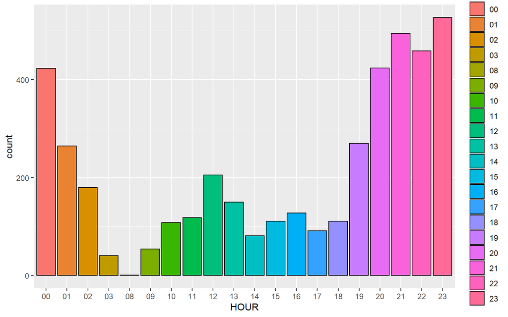

```r
heetchMday = heetchPoints %>% filter(driver_id == drivers[258])
ggplot(data = heetchMday, aes(x=HOUR, fill=HOUR)) + geom_bar(color='black')
```

### Un seul ou deux chauffeurs ?

Certains chauffeurs ayant beaucoup de temps de travail globalement, nous avons pensé à des chauffeurs avec leur compte Heetch qui maintiennet le système de shift des taxis marocains qui consiste en deux chauffeurs qui prennent le relais le jour et la nuit.

```r
# Premier chauffeur
First_driver <- heetchPoints %>%
  filter(driver_id == drivers[258]) %>%
  filter(HOUR == "02") %>%
  arrange(location_at_local_time)
```

```r
# Deuxième chauffeur
Second_driver <- heetchPoints %>%
  filter(driver_id == drivers[258]) %>%
  filter(HOUR == "09") %>%
  arrange(location_at_local_time)
```

```r
leaflet() %>%
  addTiles() %>%
  addCircles(data = First_driver, color = "red") %>%
  addCircles(data = Second_driver, color = "blue")
```

[interactive chart not shown]

### Chauffeur diurne

```r
temp_2 = heetchPoints %>%
    filter(driver_id == drivers[539]) %>%
    arrange(location_at_local_time)
Jour_2 = temp_2 %>% filter(between(HOUR, 7, 19))
Nuit_2 = setdiff(temp_2, Jour_2)
leaflet() %>%
  addTiles() %>%
  addCircles(data = Jour_2, color = "red") %>%
  addCircles(data = Nuit_2, color = "blue")
```

[interactive chart not shown]

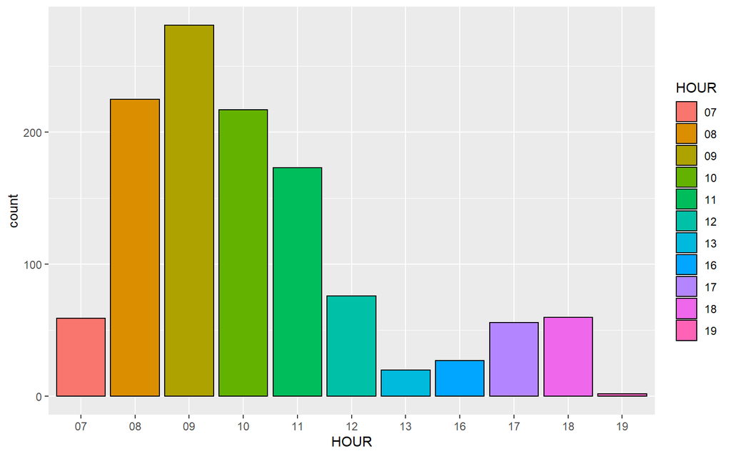

```r
heetchMday = heetchPoints %>% filter(driver_id == drivers[539])
ggplot(data = heetchMday, aes(x=HOUR, fill=HOUR)) + geom_bar(color='black')
```

## Fonctions pour les chauffeurs noctures/diurnes et chaotiques/routiniers

### Fonction is_nocturne

```r
is_nocturne = function(driver){
  temp = heetchPoints %>%
    filter(driver_id == driver) %>%
    arrange(location_at_local_time)
  Jour = temp %>% filter(between(HOUR, 7, 19))
  Nuit = setdiff(temp, Jour)
  Jour_h = nrow(Jour)
  Nuit_h = nrow(Nuit)
  if (Jour_h > Nuit_h){
    noct = 0
  }
  else {
    noct = 1
  }
  return(noct)
}
```

### Fonction is_chaotique

```r
is_chaos = function(driver){
  temp = heetchPoints %>%
    filter(driver_id == driver) %>%
    arrange(location_at_local_time)
  Jour = temp %>% filter(between(HOUR, 7, 19))
  Nuit = setdiff(temp, Jour)
  Jour_h = nrow(Jour)
  Nuit_h = nrow(Nuit)
  if (Jour_h > 0.7*Nuit_h){
    chaos = 0
  }
  else if (Jour_h < 0.7*Nuit_h) {
    chaos = 0
  }
  else {
    chaos = 1
  }
  return(chaos)
}
```

## Méthode finale : DBSCAN + Home Range + Critère de chauffeur nocturne/diurne

```r
oneDriver <- heetchPoints %>%
  filter(driver_id == drivers[258]) %>%
  arrange(location_at_local_time)

vecDif <- oneDriver$location_at_local_time[2:nrow(oneDriver)] -
  oneDriver$location_at_local_time[1:nrow(oneDriver)-1]

# sélection des points avec seuil à 8h en fonction du statut nocturne/diurne
if (is_nocturne(drivers[258]) == 1){
    idOff <- which(as.numeric(vecDif) > 480) + 1
}else {
    idOff <- which(as.numeric(vecDif) > 480)
  }
homeList <- oneDriver[idOff, ]
```

```r
coord <- st_coordinates(homeList)
db_new = dbscan(coord,eps = 0.002, minPts = 3, borderPoints = FALSE)
clusters_new <- cbind(homeList, ClusterNum = db_new$cluster)%>%
  filter(ClusterNum == 1)

clustered_home<- as_Spatial(clusters_new$geometry)

Home_range_new <- mcp(clustered_home, percent = 100)
Home_poly <- spTransform(Home_range_new, CRS("+proj=longlat +datum=WGS84"))

leaflet() %>%
  addTiles() %>%
  addCircles(data = clusters_new$geometry) %>%
  addPolygons(data = Home_poly, weight = 0 ,col = alpha(1:5, 1.5))
```

[interactive chart not shown]

## Conclusion

Tout au long de cette période, nous avons eu l’occasion, à travers nos recherches personnelles mais également grâce aux différents cours et thématiques abordées, de découvrir différentes méthodes de détection de domicile et de clustering des chauffeurs (nocturne/diurne, routinier/chaotique, etc.) et également d’avoir une vue plus globale sur l’entreprise Heetch et leur relation avec le Big Data, ce qu’ils en font et ce qu’ils pourraient éventuellement en faire.

Jusqu’à présent, grâce à l’exceptionnelle transformation sociétale et sociale que les biens et services liés aux Big Data ont apportée à l’homme depuis deux ou trois décennies, les inconvénients n’ont guère été mis en avant. La prise de conscience montante par rapport à certains points, notamment le caractère personnel de certaines données ou encore la fiscalité, obligera certaines entreprises à s’en tiendre de plus en plus aux réglementations.

## Webographie

[1] https://www.datadreaming.org/post/r-markdown-theme-gallery/  
[2] https://www.researchgate.net/publication/316553966_Home_Range_Estimation  
[3] https://iopscience.iop.org/article/10.1088/1755-1315/31/1/012012/pdf